# Quantified Self Movement Data Analysis Report

Beelie

January 31, 2016

GitHub repo: https://github.com/b33lie/practical_machine_learning.github.io/tree/gh-pages

RPubs: http://rpubs.com/b33lie/148703

## Introduction

Using devices such as Jawbone Up, Nike FuelBand, and Fitbit it is now possible to collect a large amount of data about personal activity relatively inexpensively. These type of devices are part of the quantified self movement - a group of enthusiasts who take measurements about themselves regularly to improve their health, to find patterns in their behavior, or because they are tech geeks. One thing that people regularly do is quantify how much of a particular activity they do, but they rarely quantify how well they do it. In this project, our goal will be to use data from accelerometers on the belt, forearm, arm, and dumbell of 6 participants. They were asked to perform barbell lifts correctly and incorrectly in 5 different ways. More information is available from the website here: http://groupware.les.inf.puc-rio.br/har (see the section on the Weight Lifting Exercise Dataset).

## Data Preprocessing

The training data for this project are available at:

https://d396qusza40orc.cloudfront.net/predmachlearn/pml-training.csv

The test data are available at:

https://d396qusza40orc.cloudfront.net/predmachlearn/pml-testing.csv

```r
library(lattice)
library(ggplot2)
library(caret)
library(rpart)
library(rpart.plot)
library(randomForest)
library(corrplot)
library(RColorBrewer)
library(rattle)
library(utils)
```

#### Download and Read Data

Let’s download data from link above and read data for processing.

```r
trainUrl <-"https://d396qusza40orc.cloudfront.net/predmachlearn/pml-training.csv"
testUrl <- "https://d396qusza40orc.cloudfront.net/predmachlearn/pml-testing.csv"
trainFile <- "./data/pml-training.csv"
testFile  <- "./data/pml-testing.csv"
if (!file.exists("./data")) {
  dir.create("./data")
}
if (!file.exists(trainFile)) {
  download.file(trainUrl, destfile=trainFile, method="curl")
}
if (!file.exists(testFile)) {
  download.file(testUrl, destfile=testFile, method="curl")
}
trainRaw <- read.csv("./data/pml-training.csv", na.strings=c("NA","#DIV/0!",""))
testRaw <- read.csv("./data/pml-testing.csv", na.strings=c("NA","#DIV/0!",""))
dim(trainRaw)
```

```
## [1] 19622   160
```

```r
dim(testRaw)
```

```
## [1]  20 160
```

The training data set contains 19622 observations and 160 variables, while the testing data set contains 20 observations and 160 variables. The “classe” variable in the training set is the outcome to predict.

#### Cleaning Data

Next, we will clean the data and get rid of observations with missing values as well as some meaningless variables.

First, we remove columns that contain NA missing values.

```r
sum(complete.cases(trainRaw))
```

```
## [1] 0
```

```r
trainRaw <- trainRaw[, colSums(is.na(trainRaw)) == 0]
testRaw <- testRaw[, colSums(is.na(testRaw)) == 0]
```

Next, we get rid of some columns that do not contribute much to the accelerometer measurements.

```r
classe <- trainRaw$classe
trainRemove <- grepl("^X|timestamp|window", names(trainRaw))
trainRaw <- trainRaw[, !trainRemove]
trainCleaned <- trainRaw[, sapply(trainRaw, is.numeric)]
dim(trainCleaned)
```

```
## [1] 19622    52
```

```r
trainCleaned$classe <- classe
testRemove <- grepl("^X|timestamp|window", names(testRaw))
testRaw <- testRaw[, !testRemove]
testCleaned <- testRaw[, sapply(testRaw, is.numeric)]
dim(testCleaned)
```

```
## [1] 20 53
```

Now, the cleaned training data set contains 19622 observations and 53 variables, while the testing data set contains 20 observations and 53 variables. The “classe” variable is still in the cleaned training set.

#### Partioning Data

Now we partionaing cleaned training set into a pure training data set (70%) and a validation data set (30%). We will use the validation data set to conduct cross validation in future steps.

```r
set.seed(22519) # For reproducibile purpose
inTrain <- createDataPartition(trainCleaned$classe, p=0.70, list=FALSE)
trainData <- trainCleaned[inTrain, ]
testData <- trainCleaned[-inTrain, ]
dim(trainData)
```

```
## [1] 13737    53
```

```r
dim(testData)
```

```
## [1] 5885   53
```

Now, we has pure training data set contains 13737 observations and 53 variables and validation data set contains 5885 observations and 53 variables.

## Data Modeling

#### ML algorithms for perdiction : Decision Tree

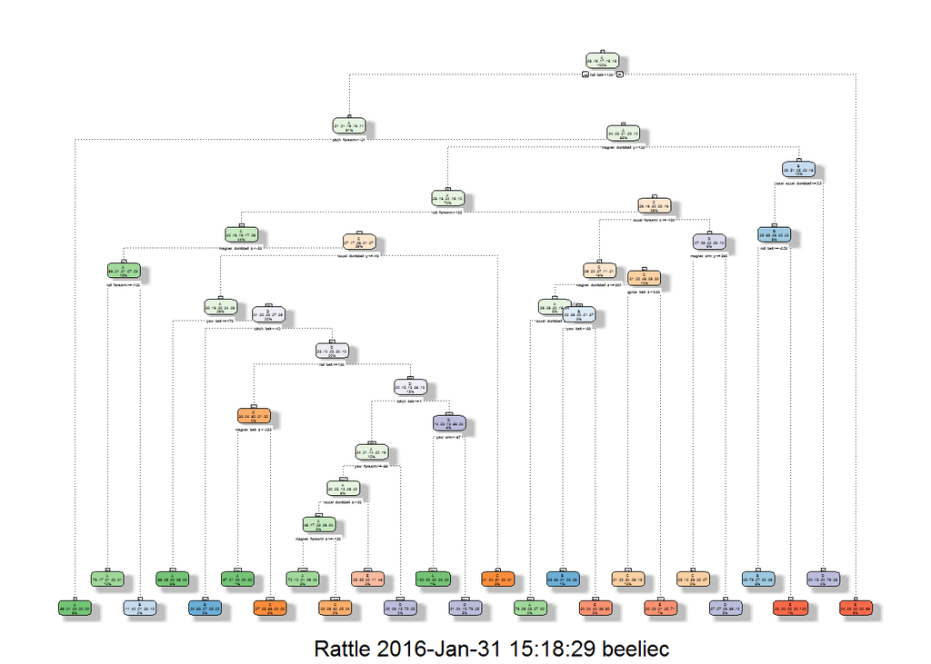

```r
modFitA1 <- rpart(classe ~ ., data=trainData, method="class")
fancyRpartPlot(modFitA1)
```

Predicting:

```r
predictionsA1 <- predict(modFitA1, testData, type = "class")
```

we estimate the performance of the model on the validation dataset.

```r
# Confusion Matrix
confusionMatrix(predictionsA1, testData$classe)
```

```
## Confusion Matrix and Statistics
##
##           Reference
## Prediction    A    B    C    D    E
##          A 1529  168   25   62    3
##          B   51  577   38   63   73
##          C   41  228  883  102  132
##          D   19   87   78  660   73
##          E   34   79    2   77  801
##
## Overall Statistics
##
##                Accuracy : 0.7562
##                  95% CI : (0.745, 0.7671)
##     No Information Rate : 0.2845
##     P-Value [Acc > NIR] : < 2.2e-16
##
##                   Kappa : 0.6912
##  Mcnemar's Test P-Value : < 2.2e-16
##
## Statistics by Class:
##
##                      Class: A Class: B Class: C Class: D Class: E
## Sensitivity            0.9134  0.50658   0.8606   0.6846   0.7403
## Specificity            0.9387  0.95259   0.8965   0.9478   0.9600
## Pos Pred Value         0.8556  0.71945   0.6371   0.7197   0.8066
## Neg Pred Value         0.9646  0.88944   0.9682   0.9388   0.9426
## Prevalence             0.2845  0.19354   0.1743   0.1638   0.1839
## Detection Rate         0.2598  0.09805   0.1500   0.1121   0.1361
## Detection Prevalence   0.3037  0.13628   0.2355   0.1558   0.1687
## Balanced Accuracy      0.9261  0.72959   0.8786   0.8162   0.8502
```

```r
accuracyA1 <- postResample(predictionsA1, testData$classe)
accuracyA1
```

```
##  Accuracy     Kappa
## 0.7561597 0.6912016
```

```r
ooseA1 <- 1 - as.numeric(confusionMatrix(testData$classe, predictionsA1)$overall[1])
ooseA1
```

```
## [1] 0.2438403
```

So, the estimated accuracy of the model is 75.62% and the estimated out-of-sample error is 24.38%.

#### ML algorithms for perdiction : Random Forests

```r
modFitB1 <- randomForest(classe ~. , data=trainData)
```

```r
predictionsB1 <- predict(modFitB1, testData, type = "class")
```

we estimate the performance of the model on the validation dataset.

```r
# Confusion Matrix
confusionMatrix(predictionsB1, testData$classe)
```

```
## Confusion Matrix and Statistics
##
##           Reference
## Prediction    A    B    C    D    E
##          A 1673    2    0    0    0
##          B    0 1135    1    0    0
##          C    0    2 1023   16    0
##          D    0    0    2  947    4
##          E    1    0    0    1 1078
##
## Overall Statistics
##
##                Accuracy : 0.9951
##                  95% CI : (0.9929, 0.9967)
##     No Information Rate : 0.2845
##     P-Value [Acc > NIR] : < 2.2e-16
##
##                   Kappa : 0.9938
##  Mcnemar's Test P-Value : NA
##
## Statistics by Class:
##
##                      Class: A Class: B Class: C Class: D Class: E
## Sensitivity            0.9994   0.9965   0.9971   0.9824   0.9963
## Specificity            0.9995   0.9998   0.9963   0.9988   0.9996
## Pos Pred Value         0.9988   0.9991   0.9827   0.9937   0.9981
## Neg Pred Value         0.9998   0.9992   0.9994   0.9966   0.9992
## Prevalence             0.2845   0.1935   0.1743   0.1638   0.1839
## Detection Rate         0.2843   0.1929   0.1738   0.1609   0.1832
## Detection Prevalence   0.2846   0.1930   0.1769   0.1619   0.1835
## Balanced Accuracy      0.9995   0.9981   0.9967   0.9906   0.9979
```

```r
accuracyB1 <- postResample(predictionsB1, testData$classe)
accuracyB1
```

```
##  Accuracy     Kappa
## 0.9950722 0.9937668
```

```r
ooseB1 <- 1 - as.numeric(confusionMatrix(testData$classe, predictionsB1)$overall[1])
ooseB1
```

```
## [1] 0.004927782
```

So, the estimated accuracy of the model is 99.5% and the estimated out-of-sample error is 0.49%.

## Predicting for Test Data Set

Now, we apply the model to the original testing data set downloaded from the data source.

```r
result <- predict(modFitB1, testCleaned[, -length(names(testCleaned))])
result
```

```
##  1  2  3  4  5  6  7  8  9 10 11 12 13 14 15 16 17 18 19 20
##  B  A  B  A  A  E  D  B  A  A  B  C  B  A  E  E  A  B  B  B
## Levels: A B C D E
```